# Facebook Analysis

Fernando Hernández Esquivel

26 de mayo de 2019

Lo que deseo con este ejercicio es tratar de obtener información útil de los contactos que tengo agregados a mi cuenta de Facebook a través de un breve análisis sobre la información que cada uno de los usuarios permite publicar en su perfil público o en el enlace que genera Facebook para la identificación de los mismos.La información se toma del apartado “Amigos”.

Comenzamos con la carga de paqueterías

```r
library(dplyr)
library(stringr)
library(syuzhet)
library(tm)
library(wordcloud)
library(RColorBrewer)
```

Se carga la base de datos previamente creada en Excel, y revisamos la estructura de la base, vemos algunos de los datos y realizamos un summary

```r
fbFr<-read.csv("C:/Users/fehee/Desktop/tfbF.csv",encoding = "Unicode")
str(fbFr)
```

```
## 'data.frame':    1494 obs. of  1 variable:
##  $ Nombre: Factor w/ 674 levels "????? ?.","?????? ???????",..: 486 410 308 309 312 153 308 309 653 80 ...
```

```r
head(fbFr,10)
```

```
##                       Nombre
## 1            Karla Rodríguez
## 2  Facultad de Medicina UAEM
## 3                      Amigo
## 4                     Amigos
## 5    Anastassiya Khusnullina
## 6                 422 amigos
## 7                      Amigo
## 8                     Amigos
## 9                 Val Rangel
## 10               2309 amigos
```

```r
tail(fbFr,10)
```

```
##                         Nombre
## 1485 Inés Marmissolle Daguerre
## 1486                744 amigos
## 1487                     Amigo
## 1488                    Amigos
## 1489             Bianca Aguayo
## 1490               4503 amigos
## 1491                     Amigo
## 1492                    Amigos
## 1493               Lily Avalos
## 1494         2 amigos en común
```

```r
head(summary(fbFr),10)
```

```
##                 Nombre
##  Amigos            :374
##  Amigo             :373
##  13 amigos en común:  8
##  2 amigos en común :  8
##  12 amigos en común:  5
##  15 amigos en común:  4
##  (Other)           :722
```

Al analizar la base con detenimiento notamos que algunos contactos no muestran ningún tipo de información mas que el nombre, por lo que hacemos una subdivisión de la tabla, que nos permita obtener los datos funcionales para nuestro análisis. Por lo que sacamos de la tabla las variables que se repiten muchas veces y los contactos que no muestran información adicional y revisamos los datos

```r
fbFr1<-subset(fbFr, Nombre!="Amigo" & Nombre!="Amigos" & Nombre!="Conocido" & Nombre!="Serch David" &
               Nombre!="Claudia Berenice Ol" & Nombre!= "Ralph Arzaluz" & Nombre!="Cartelera Teatro En Toluca")
```

```r
head(fbFr1,10)
```

```
##                                                                           Nombre
## 1                                                                Karla Rodríguez
## 2                                                      Facultad de Medicina UAEM
## 5                                                        Anastassiya Khusnullina
## 6                                                                     422 amigos
## 9                                                                     Val Rangel
## 10                                                                   2309 amigos
## 13                                                               Ana Karen Mejia
## 14                                                            71 amigos en común
## 17                                                             Rosanna Archundia
## 18 R3 Medicina Familiar Servicio Social en Hospital Rural Prospera IMSS Mamantel
```

```r
tail(fbFr1,10)
```

```
##                         Nombre
## 1477            Natasha Alicia
## 1478                576 amigos
## 1481                Erik López
## 1482               1141 amigos
## 1485 Inés Marmissolle Daguerre
## 1486                744 amigos
## 1489             Bianca Aguayo
## 1490               4503 amigos
## 1493               Lily Avalos
## 1494         2 amigos en común
```

A la tabla obtenida le asignaremos un idetificador para poder dividir la tabla en 2 variables, la primera de ellas será “Nombre” y la segunda “Info”

```r
ID<-rep(1:2,371)
fbFr1<-cbind(ID,fbFr1)
head(fbFr1,9)
```

```
##    ID                    Nombre
## 1   1           Karla Rodríguez
## 2   2 Facultad de Medicina UAEM
## 5   1   Anastassiya Khusnullina
## 6   2                422 amigos
## 9   1                Val Rangel
## 10  2               2309 amigos
## 13  1           Ana Karen Mejia
## 14  2        71 amigos en común
## 17  1         Rosanna Archundia
```

```r
Nombre<-subset(fbFr1, ID==1)
Info<-subset(fbFr1, ID==2)
fbFr2<-cbind(Nombre,Info)
head(fbFr2,10)
```

```
##    ID                  Nombre ID
## 1   1         Karla Rodríguez  2
## 5   1 Anastassiya Khusnullina  2
## 9   1              Val Rangel  2
## 13  1         Ana Karen Mejia  2
## 17  1       Rosanna Archundia  2
## 21  1         Hec Man Peralta  2
## 25  1             Victor Lara  2
## 29  1              Rosa María  2
## 33  1    Jesus Manuel Pech Ku  2
## 37  1    Carolina Villafuerte  2
##                                                                           Nombre
## 1                                                      Facultad de Medicina UAEM
## 5                                                                     422 amigos
## 9                                                                    2309 amigos
## 13                                                            71 amigos en común
## 17 R3 Medicina Familiar Servicio Social en Hospital Rural Prospera IMSS Mamantel
## 21                                                                    813 amigos
## 25                                                            61 amigos en común
## 29                                                                    386 amigos
## 33                                                                   1913 amigos
## 37                                                            23 amigos en común
```

A la tabla creada se le borrará el identificador, pero se le agregará un índice de contacto, y finalmente, se le dará formato

```r
N.C<-seq(1,371,1)
fbFr3<-cbind(N.C,fbFr2[,-c(1,3)])
colnames(fbFr3)<-c("No.Contacto","Nombre","Info")
head(fbFr3,10)
```

```
##    No.Contacto                  Nombre
## 1            1         Karla Rodríguez
## 5            2 Anastassiya Khusnullina
## 9            3              Val Rangel
## 13           4         Ana Karen Mejia
## 17           5       Rosanna Archundia
## 21           6         Hec Man Peralta
## 25           7             Victor Lara
## 29           8              Rosa María
## 33           9    Jesus Manuel Pech Ku
## 37          10    Carolina Villafuerte
##                                                                             Info
## 1                                                      Facultad de Medicina UAEM
## 5                                                                     422 amigos
## 9                                                                    2309 amigos
## 13                                                            71 amigos en común
## 17 R3 Medicina Familiar Servicio Social en Hospital Rural Prospera IMSS Mamantel
## 21                                                                    813 amigos
## 25                                                            61 amigos en común
## 29                                                                    386 amigos
## 33                                                                   1913 amigos
## 37                                                            23 amigos en común
```

Ahora agregamos los nombres que al principio se quitaron de la tabla

```r
fbFr3<-fbFr3%>%add_row(No.Contacto=372,Nombre="Serch David",Info=NA)
fbFr3<-fbFr3%>%add_row(No.Contacto=373,Nombre="Claudia Berenice Ol",Info=NA)
fbFr3<-fbFr3%>%add_row(No.Contacto=374,Nombre="Ralph Arzaluz",Info=NA)
fbFr3<-fbFr3%>%add_row(No.Contacto=375,Nombre="Cartelera Teatro En Toluca",Info=NA)
tail(fbFr3,10)
```

```
##     No.Contacto                     Nombre              Info
## 366         366 Miguel Angel Aguirre Pitol       1733 amigos
## 367         367             Natasha Alicia        576 amigos
## 368         368                 Erik López       1141 amigos
## 369         369  Inés Marmissolle Daguerre        744 amigos
## 370         370              Bianca Aguayo       4503 amigos
## 371         371                Lily Avalos 2 amigos en común
## 372         372                Serch David              <NA>
## 373         373        Claudia Berenice Ol              <NA>
## 374         374              Ralph Arzaluz              <NA>
## 375         375 Cartelera Teatro En Toluca              <NA>
```

En la revisión previa a la tabla principal se encontró que 3 de los contactos usan una configuración de idioma diferente, por lo que se tomaron los nombres y se transformaron a UTF-8, y se sustituyeron en la tabla que hemos obtenido en el código anterior, para ello se transforma a “character” las variables “Nombre” e “Info”

```r
fbFr3$Nombre<-as.character(fbFr3$Nombre)
fbFr3$Info<-as.character(fbFr3$Info)
fbFr3[37,c(2)]<-"Anastasia Shchekina"
fbFr3[40,c(2)]<-"Yanina S."
fbFr3[151,c(2)]<-"Hernandez Cristian."
fbFr3[c(37,40,151),]
```

```
##     No.Contacto              Nombre        Info
## 37           37 Anastasia Shchekina 4934 amigos
## 40           40           Yanina S.   93 amigos
## 151         151 Hernandez Cristian.  308 amigos
```

Análisis de los datos

Una vez creada la tabla que contiene la información se procede al análisis. Primero contaremos las palabras contenidas en cada observación de la variable “Nombre”

```r
str_count(fbFr3$Nombre, "\\w+")
```

```
##   [1] 2 2 2 3 2 3 2 2 4 2 2 3 2 4 2 2 2 4 2 3 2 2 4 2 3 2 2 2 2 2 3 2 2 3 2
##  [36] 6 2 2 2 2 2 2 2 3 3 4 3 3 2 2 2 2 2 2 2 3 2 2 3 2 2 3 3 3 4 2 2 2 2 2
##  [71] 2 2 3 2 2 2 2 2 3 3 2 2 2 2 2 2 2 4 3 2 2 2 2 2 2 3 3 4 3 3 2 3 3 2 3
## [106] 2 2 3 2 4 2 2 4 2 3 2 4 2 3 2 2 2 2 3 2 2 2 2 3 3 2 2 2 2 2 3 2 3 3 3
## [141] 3 3 2 4 4 2 4 2 2 3 2 3 2 2 2 2 4 3 3 2 2 3 2 2 2 3 3 3 2 2 2 4 4 2 2
## [176] 2 3 2 2 3 2 2 3 4 2 2 3 4 2 2 4 2 4 2 2 3 2 2 2 2 4 2 2 2 3 2 2 2 3 2
## [211] 2 4 2 2 2 3 2 3 2 2 2 3 3 3 3 2 2 4 2 3 2 2 3 2 4 3 3 3 4 3 2 2 2 4 3
## [246] 2 2 2 2 4 2 3 3 3 3 3 4 2 3 2 2 3 2 2 2 2 2 2 2 2 4 2 3 3 2 3 2 3 2 2
## [281] 3 2 3 4 3 3 2 2 2 2 2 2 2 2 2 2 4 4 2 3 2 2 2 3 2 3 2 2 2 3 4 2 3 3 3
## [316] 2 2 4 2 2 3 3 2 3 2 3 2 2 3 2 3 2 4 3 2 2 2 2 2 2 3 3 2 4 2 2 3 2 2 2
## [351] 2 2 3 4 2 3 2 3 3 2 2 2 2 1 2 4 2 2 3 2 2 2 3 2 4
```

```r
c_w<-cbind(min(str_count(fbFr3$Nombre, "\\w+")),max(str_count(fbFr3$Nombre, "\\w+")),mean(str_count(fbFr3$Nombre, "\\w+")))
c_w<-data.frame(c_w)
names(c_w)<-c("Min","Max","Media")
c_w
```

```
##   Min Max    Media
## 1   1   6 2.501333
```

Como se puede observar en la variable “Nombre” la observación con el mínimo valor de palabras es 1 y el máximo de palabras es 6, el promedio de palabras en la variable está entre 2 y 3 palabras

Revisamos que contactos son los que tienen los valores mínimo y máximo

```r
fbFr3$Nombre[str_count(fbFr3$Nombre, "\\w+")==1]
```

```
## [1] "Pibo"
```

```r
fbFr3$Nombre[str_count(fbFr3$Nombre, "\\w+")==6]
```

```
## [1] "Angelika Pauli Jimenez Chaveez de Cuauhtli"
```

Ahora contaremos el número de letras por observación en la misma variable

```r
str_length(fbFr3$Nombre)
```

```
##   [1] 15 23 10 15 17 15 11 10 20 20 17 21  7 27 13 14 13 32 11 17 11 13 25
##  [24] 14 12 12 12 12 12 11 18 12 11 24 12 42 19 11 20  9 10 10 16 20 19 32
##  [47] 22 17 13 14 10 16 19 12 16 22 15 13 18 15 14 13 20 25 25 14 14 11 17
##  [70] 11 14 15 18 14 12 12 15 11 23 19 12 16  8 10 13 15 13 28 19 16 16 17
##  [93] 15 12 10 19 21 28 17 14  5 18 15 11 20 11 13 20 11 34 10 10 27 10 18
## [116] 18 27 10 26 13 16 14 13 18 10 14 11 11 18 24 17 10 15 12 12 17 13 33
## [139] 21 19 15 20 10 35 18 11 18 13 11 18 19 21 15  9 13 15 25 20 21 14  7
## [162] 17 11 15 11 16 18 20 13 15 14 21 30 14 10 12 17 17 13 23 16 13 25 26
## [185] 12 12 25 33 15 13 30 17 32  8  9 20 15 15 13 12 33 10 12 16 23 14 10
## [208] 10 25 15 14 35 16 12 11 21 13 20 11 12  7 16 21 15 14 11 12 21 12 17
## [231] 15 16 15 11 26 27 35 19 27 23  9 12  9 25 19 10 14 13  9 22 17 23 24
## [254] 24 22 21 22 10 24 12 15 18 13 14 15 18 12 10 11 13 31 11 22 18 15 17
## [277] 10 17 13 15 11 14 24 30 16 17 12 11 12 12 14 18 13 13 10 19 27 27 12
## [300] 24 12  9  8 17 11 17 17 16 13 21 29 11 14 18 24 11 16 28 10 14 20 19
## [323] 14 11 16 18  9 11 22 13 15 17 28 14 17 15 11  6 12 11 13 18 11 28 12
## [346] 11 20 14 12 16 17 11 15 22 18 26 14 18 25 15 15 13 13  4 12 26 14 10
## [369] 25 13 11 11 19 13 26
```

```r
c_l<-cbind(min(str_length(fbFr3$Nombre)),max(str_length(fbFr3$Nombre)),mean(str_length(fbFr3$Nombre)))
c_l<-data.frame(c_l)
names(c_l)<-c("Min","Max","Media")
c_l
```

```
##   Min Max Media
## 1   4  42 16.32
```

Como se puede observar el valor mínimo de letras obtenido por observación es de 4 y el valor máximo es de 42, con un promedio de 16 palabras para esta variable

Volvemos a revisar que observaciones son las que poseen el mínimo y máximo obtenidos

```r
fbFr3$Nombre[str_length(fbFr3$Nombre)==4]
```

```
## [1] "Pibo"
```

```r
fbFr3$Nombre[str_length(fbFr3$Nombre)==42]
```

```
## [1] "Angelika Pauli Jimenez Chaveez de Cuauhtli"
```

En este caso son la mismas observaciones que en el análisis de número de palabras, sin embargo, no siempre resulta ser así, por ejemplo, si usaramos un texto donde existen las siguientes cadenas de caracteres: “sí, sí te vi ayer” y “potentemente y velozmente arremetio saliendo”, ambas cadenas contienen 5 palabras, pero no el mismo número de letras

Finalmente, analizaremos el número de espacios en blanco en la variable “Nombre”

```r
str_count(fbFr3$Nombre, "[[:blank:]]")
```

```
##   [1] 1 1 1 2 1 2 1 1 3 1 1 2 1 3 1 1 1 3 1 2 1 1 3 1 2 1 1 1 1 1 2 1 1 2 1
##  [36] 5 1 1 1 1 1 1 1 2 2 3 2 2 1 1 1 1 1 1 1 2 1 1 2 1 1 2 2 2 3 1 1 1 1 1
##  [71] 1 1 2 1 1 1 1 1 2 2 1 1 1 1 1 1 1 3 2 1 1 1 1 1 1 2 2 3 2 2 1 2 2 1 2
## [106] 1 1 2 1 3 1 1 3 1 2 1 3 1 2 1 1 1 1 2 1 1 1 1 2 2 1 1 1 1 1 2 1 2 2 2
## [141] 2 2 1 3 3 1 3 1 1 2 1 2 1 1 1 1 3 2 2 1 1 2 1 1 1 2 2 2 1 1 1 3 3 1 1
## [176] 1 2 1 1 2 1 1 2 3 1 1 2 3 1 1 3 1 3 1 1 2 1 1 1 1 3 1 1 1 2 1 1 1 2 1
## [211] 1 3 1 1 1 2 1 2 1 1 1 2 2 2 2 1 1 3 1 2 1 1 2 1 3 2 2 2 3 2 1 1 1 3 2
## [246] 1 1 1 1 3 1 2 1 2 2 2 3 1 2 1 1 2 1 1 1 1 1 1 1 1 3 1 2 2 1 2 1 2 1 1
## [281] 2 1 2 3 2 2 1 1 1 1 1 1 1 1 1 1 3 3 1 2 1 1 1 2 1 2 1 1 1 2 3 1 2 2 2
## [316] 1 1 3 1 1 2 2 1 2 1 2 1 1 2 1 2 1 3 2 1 1 1 1 1 1 2 2 1 3 1 1 2 1 1 1
## [351] 1 1 2 3 1 2 1 2 2 1 1 1 1 0 1 3 1 1 2 1 1 1 2 1 3
```

```r
c_b<-cbind(min(str_count(fbFr3$Nombre, "[[:blank:]]")),max(str_count(fbFr3$Nombre, "[[:blank:]]")),mean(str_count(fbFr3$Nombre, "[[:blank:]]")))
c_b<-data.frame(c_b)
names(c_b)<-c("Min","Max","Media")
c_b
```

```
##   Min Max    Media
## 1   0   5 1.498667
```

El valor mínimo es de 0 espacios en blanco y el máximo es de 5, con un promedio que oscila entre 1 y 2 espacioes en blanco

Se revisan las observaciones

```r
fbFr3$Nombre[str_count(fbFr3$Nombre, "[[:blank:]]")==0]
```

```
## [1] "Pibo"
```

```r
fbFr3$Nombre[str_count(fbFr3$Nombre, "[[:blank:]]")==5]
```

```
## [1] "Angelika Pauli Jimenez Chaveez de Cuauhtli"
```

Volvemos a observar que son las mismas 2 observaciones ya conocidas.

Hecho lo anterior, pasamos a dividir los nombres para un mejor análisis

```r
N1<-as.character(str_split_fixed(fbFr3$Nombre, "[[:blank:]]",6))
N1<-data.frame(N1)
names(N1)<-"Nombre"
head(N1,10)
```

```
##         Nombre
## 1        Karla
## 2  Anastassiya
## 3          Val
## 4          Ana
## 5      Rosanna
## 6          Hec
## 7       Victor
## 8         Rosa
## 9        Jesus
## 10    Carolina
```

```r
tail(N1,10)
```

```
##      Nombre
## 2241
## 2242
## 2243
## 2244
## 2245
## 2246
## 2247
## 2248
## 2249
## 2250
```

Hemos visto que existen valores vacíos, con lo procedemos a transformarlos para después borrarlos

```r
N1$Nombre[N1$Nombre==""]=NA
N1<-subset(N1,Nombre!="NA")
tail(N1)
```

```
##        Nombre
## 1469   Vences
## 1479     Real
## 1491    Pitol
## 1500   Toluca
## 1536       de
## 1911 Cuauhtli
```

Aplicaremos una tabla de frecuencia para observar que nombres o apellidos son los más empleados por los contactos

```r
head(sort(table(N1),decreasing = TRUE),77)
```

```
## N1
## Hernandez  Esquivel      Luis Hernández    Miguel    Garcia     Karla
##        13        11        11        10         8         6         6
##     Lopez Rodriguez Francisco  González   Herrera      José   Sanchez
##         6         6         5         5         5         5         5
##    Sergio      Alan      Aldo       Ale    Carlos  Cuauhtli     David
##         5         4         4         4         4         4         4
##  Gonzalez      Lara     López  Martinez      Peña Alejandro   Alfonso
##         4         4         4         4         4         3         3
##   Alfredo    Andrea     Angel   Antonio     Avila   Barrera      Cruz
##         3         3         3         3         3         3         3
##     Diana     Diego  Emmanuel      Erik    Felipe    García     Gomez
##         3         3         3         3         3         3         3
##  Granados      Hdez     Jesus   Jimenez     Karen      León     Maria
##         3         3         3         3         3         3         3
##      Noll    Pineda    Rafael     Rojas     Solis    Torres    Ulises
##         3         3         3         3         3         3         3
## Alcantara      Alex    Alonso       Ana    Angela   Arevalo     Ayala
##         2         2         2         2         2         2         2
##  Balderas  Berenice   Berrios    Brenda     Bruno  Calavera   Camacho
##         2         2         2         2         2         2         2
##    Carmen   Claudia Contreras    Cortes    Cuevas    Daniel        de
##         2         2         2         2         2         2         2
```

En la tabla se ve claramente que hay apellidos que están escritos de diferente forma, así como algunos nombres también

Manualmente trataremos de homogeneizar los apellidos y nombres con mayor número de observaciones, cambiando las palabras con acento a palabras sin acentos

```r
t1<-str_replace_all(N1$Nombre, pattern = "Hernández", replacement = "Hernandez")
t2<-str_replace_all(t1, pattern = "García", replacement = "Garcia")
t3<-str_replace_all(t2, pattern = "López", replacement = "Lopez")
t4<-str_replace_all(t3, pattern = "Rodríguez", replacement = "Rodriguez")
t5<-str_replace_all(t4, pattern = "González", replacement = "Gonzalez")
t6<-str_replace_all(t5, pattern = "José", replacement = "Jose")
t7<-str_replace_all(t6, pattern = "Sánchez", replacement = "Sanchez")
t8<-str_replace_all(t7, pattern = "Martínez", replacement = "Martinez")
t9<-str_replace_all(t8, pattern = "Ávila", replacement = "Avila")
t10<-str_replace_all(t9, pattern = "Gómez", replacement = "Gomez")
t11<-str_replace_all(t10, pattern = "Hdez", replacement = "Hernandez")
t12<-str_replace_all(t11, pattern = "Jesús", replacement = "Jesus")
t13<-str_replace_all(t12, pattern = "Jiménez", replacement = "Jimenez")
t14<-str_replace_all(t13, pattern = "León", replacement = "Leon")
t15<-str_replace_all(t14, pattern = "María", replacement = "Maria")
t16<-str_replace_all(t15, pattern = "Solís", replacement = "Solis")
t17<-str_replace_all(t16, pattern = "Esquiveel", replacement = "Esquivel")
t18<-str_replace_all(t17, pattern = "Lpez", replacement = "Lopez")
N1F<-str_replace_all(t18, pattern = "Alcántara", replacement = "Alcantara")
head(sort(table(N1F),decreasing = TRUE),55)
```

```
## N1F
## Hernandez  Esquivel     Lopez      Luis    Garcia  Gonzalez    Miguel
##        26        12        11        11         9         9         8
##      Jose Rodriguez   Sanchez     Karla  Martinez Francisco   Herrera
##         7         7         7         6         6         5         5
##     Maria    Sergio      Alan      Aldo       Ale    Carlos  Cuauhtli
##         5         5         4         4         4         4         4
##     David   Jimenez      Lara      Peña Alejandro   Alfonso   Alfredo
##         4         4         4         4         3         3         3
##    Andrea     Angel   Antonio     Avila   Barrera      Cruz     Diana
##         3         3         3         3         3         3         3
##     Diego  Emmanuel      Erik    Felipe     Gomez  Granados     Jesus
##         3         3         3         3         3         3         3
##     Karen      Leon      Noll    Pineda    Rafael     Rojas     Solis
##         3         3         3         3         3         3         3
##    Torres    Ulises Alcantara      Alex    Alonso       Ana
##         3         3         2         2         2         2
```

Hemos conseguido una mejor agrupación, sin embargo, esto sólo se hizo para los apellidos y nombres de mayor frecuencia, para los valores de menor frecuencia, se dejarán los valores orginales

Una vez obtenida la base pasamos a crear una “Corpora” que se usa frecuentemente en análisis de sentimientos y clasificación de textos

```r
corp<-Corpus(VectorSource(N1F))
# Se quitan los signos de puntuación
corp<-tm_map(corp,removePunctuation)
# Se convierten en minúsculas todas las palabras
corp<-tm_map(corp,content_transformer(tolower))
```

Ahora se crea la matriz Term-Document, esta matriz cuenta una a una las palabras existentes en todo los documentos que contiene el corpus

```r
term.matrix<-TermDocumentMatrix(corp)
term.matrix<-as.matrix(term.matrix)
```

Una vez obtenida la matriz Term-Document, se calcúlan las frecuencias de cada nombre y apellido, ordenándose de mayor a menor frecuencia en una nueva tabla

```r
w_f<-sort(rowSums(term.matrix),decreasing=TRUE)
dm<-data.frame(word=names(w_f),freq=w_f)
head(dm,10)
```

```
##                word freq
## hernandez hernandez   26
## esquivel   esquivel   12
## luis           luis   11
## lopez         lopez   11
## garcia       garcia   10
## gonzalez   gonzalez    9
## miguel       miguel    8
## jose           jose    7
## rodriguez rodriguez    7
## sanchez     sanchez    7
```

Ya con la tabla de frecuencias, creamos un gráfico de barras

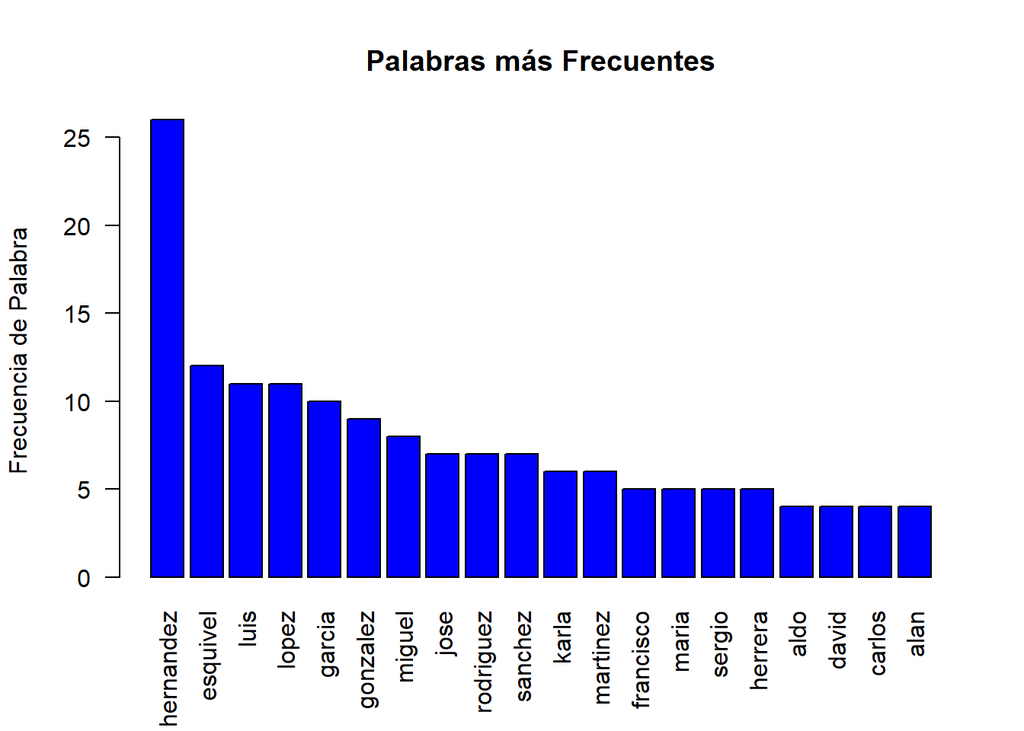

```r
barplot(dm[1:20,]$freq,las=2,names.arg=dm[1:20,]$word,
        col="blue",main="Palabras más Frecuentes",ylab="Frecuencia de Palabra")
```

Graficamos la “Word Cloud” con los datos de la tabla de frecuencia

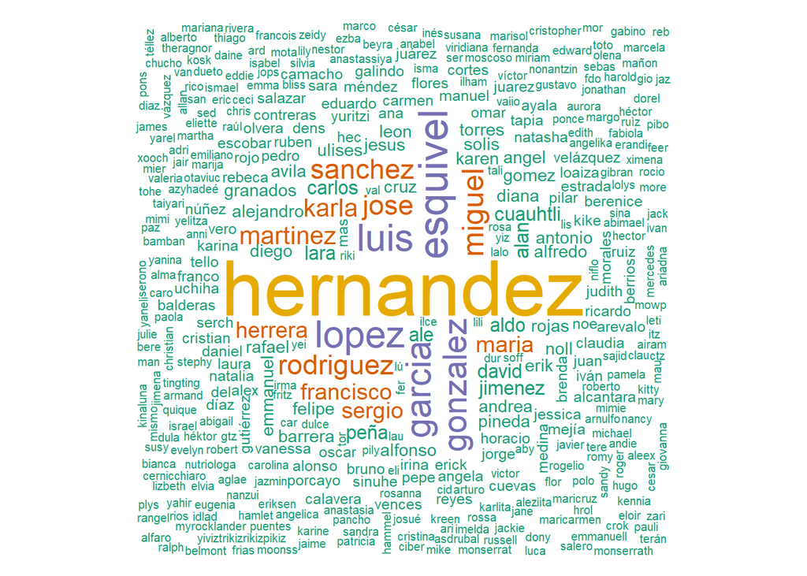

```r
wordcloud(dm$word, dm$freq, random.order=FALSE,colors=brewer.pal(6, "Dark2"),min.freq = 1)
```

Queda muy claro que los contactos que tengo agregados en su mayoría son familiares directos e indirectos(Hernández,Esquivel,López,García,Herrera), seguído de contactos con apellidos como: González, Martínez, Rodríguez, Sánchez, y en cuanto a los nombres se refiere, María,Karla,Luis,Francisco,José, Miguel y Sergio

Ahora calcularemos la frecuencia de los nombres y apellidos de cada letra, para saber con exactitud el número y procentaje. En cada una de las siguientes tablas se pueden ver las veces que los nombres y apellidos se han contado

```r
# a
nA<-unlist(str_extract_all(N1F,"A[:alpha:]{1,}"))
nA1<-sort(table(nA),decreasing = TRUE)
A<-sum(nA1)
Ap<-sum(nA1)/sum(length(N1F))*100
nA1
```

```
## nA
##        Alan        Aldo         Ale   Alejandro     Alfonso     Alfredo
##           4           4           4           3           3           3
##      Andrea       Angel     Antonio       Avila   Alcantara        Alex
##           3           3           3           3           2           2
##      Alonso         Ana      Angela     Arevalo       Ayala     Abasolo
##           2           2           2           2           2           1
##     Abigail     Abimael       Abril         Aby   Accsorios        Adri
##           1           1           1           1           1           1
##       Aglae      Aguayo    Aguilera     Aguirre       Airam      Alanis
##           1           1           1           1           1           1
##     Alberto     Alcaraz       Aleex       Aleph      Alexia    Aleziita
##           1           1           1           1           1           1
##      Alfaro      Alicia       Allan        Alma   Ambulante     Amezcua
##           1           1           1           1           1           1
##      Anabel   Anastasia Anastassiya       Anaya       Andie  Angelanora
##           1           1           1           1           1           1
##     Angeles    Angelica    Angelika      Anguel        Anni     Anzurez
##           1           1           1           1           1           1
##   Archundia         Ard   Argüelles         Ari     Ariadna      Armand
##           1           1           1           1           1           1
##     Armando     Arnulfo    Arrazola   Arredondo      Arturo     Arzaluz
##           1           1           1           1           1           1
##    Asdrubal      Aurora      Avalos       Azpra    Azyhadeé
##           1           1           1           1           1
```

```r
# b
nB<-unlist(str_extract_all(N1F,"B[:alpha:]{1,}"))
nB1<-sort(table(nB),decreasing = TRUE)
B<-sum(nB1)
Bp<-sum(nB1)/sum(length(N1F))*100
nB1
```

```
## nB
##   Barrera  Balderas  Berenice   Berrios    Brenda     Bruno   Badillo
##         3         2         2         2         2         2         1
##     Baeza    Bamban    Barrón   Bastida  Bautista Belcastro   Belmont
##         1         1         1         1         1         1         1
##      Bere     Beyra    Bianca     Bliss      Borá    Borras   Botello
##         1         1         1         1         1         1         1
##     Bravo
##         1
```

```r
# c
nC<-unlist(str_extract_all(N1F,"C[:alpha:]{1,}"))
nC1<-sort(table(nC),decreasing = TRUE)
C<-sum(nC1)
Cp<-sum(nC1)/sum(length(N1F))*100
nC1
```

```
## nC
##       Carlos     Cuauhtli         Cruz     Calavera      Camacho
##            4            4            3            2            2
##       Carmen      Claudia    Contreras       Cortes     Cristian
##            2            2            2            2            2
##       Cuevas    Caballero       Cancri       Cantos          Car
##            2            1            1            1            1
##     Carballo      Carmond         Caro     Carolina    Cartelera
##            1            1            1            1            1
##     Casillas    Castañeda     Castillo       Castro     Ceballos
##            1            1            1            1            1
##         Ceci Cernicchiaro       Cervón        Cesar        César
##            1            1            1            1            1
##      Chalico      Chaveez       Chávez       Cheros  Chistiakova
##            1            1            1            1            1
##        Chris    Christian       Chucho        Ciber          Cid
##            1            1            1            1            1
##         Clau      Claudio           Co        Coeto     Corneliu
##            1            1            1            1            1
##     Coronado           CQ     Cristina   Cristopher         Crok
##            1            1            1            1            1
##          Ctz      Cynthia
##            1            1
```

```r
# d
nD<-unlist(str_extract_all(N1F,"D[:alpha:]{1,}"))
nD1<-sort(table(nD),decreasing = TRUE)
D<-sum(nD1)
Dp<-sum(nD1)/sum(length(N1F))*100
nD1
```

```
## nD
##    David    Diana    Diego Daguerre   Daniel      Del     Dens     Díaz
##        4        3        3        2        2        2        2        2
##    Daine   Damian  Diavolo     Diaz     Dony    Dorel    Dueto     Dula
##        1        1        1        1        1        1        1        1
##    Dulce      Dur    Duran
##        1        1        1
```

```r
# e
nE<-unlist(str_extract_all(N1F,"E[:alpha:]{1,}"))
nE1<-sort(table(nE),decreasing = TRUE)
E<-sum(nE1)
Ep<-sum(nE1)/sum(length(N1F))*100
nE1
```

```
## nE
##  Esquivel  Emmanuel      Erik   Eduardo     Erick   Escobar   Estrada
##        12         3         3         2         2         2         2
## Echegaray        Ed        ED     Eddie     Edith    Edward     Elena
##         1         1         1         1         1         1         1
##       Eli   Eliette     Eloir     Elvia  Emiliano      Emma Emmanuell
##         1         1         1         1         1         1         1
##        En    Erandi      Eric   ErikSen  Escobedo Espindola  Espinosa
##         1         1         1         1         1         1         1
##    Esross Estefanía   Eugenia    Evelyn      Ezba
##         1         1         1         1         1
```

```r
# f
nF<-unlist(str_extract_all(N1F,"F[:alpha:]{1,}"))
nF1<-sort(table(nF),decreasing = TRUE)
Fe<-sum(nF1)
Fp<-sum(nF1)/sum(length(N1F))*100
nF1
```

```
## nF
## Francisco    Felipe    Flores    Franco   Fabiola       Fdo      Feer
##         5         3         2         2         1         1         1
##       Fer Feregrino  Fernanda  Fernando    Ferrer  Figueroa      Flor
##         1         1         1         1         1         1         1
## Francioli  Francois     Frias     Fritz
##         1         1         1         1
```

```r
# g
nG<-unlist(str_extract_all(N1F,"G[:alpha:]{1,}"))
nG1<-sort(table(nG),decreasing = TRUE)
G<-sum(nG1)
Gp<-sum(nG1)/sum(length(N1F))*100
nG1
```

```
## nG
##     Garcia   Gonzalez      Gomez   Granados    Galindo  Gutiérrez
##          9          9          3          3          2          2
##     Gabino       GaCo     Garcam     GaRcia    Garduño       Gdma
##          1          1          1          1          1          1
##     Gibran     Gilbon        Gio   Giovanna   Giovanni       GoHe
##          1          1          1          1          1          1
##   Goicolea      Golan   Gonzàlez      GoVaz   Gregorio        Gtz
##          1          1          1          1          1          1
##  Guadalupe Guadarrama  Guarneros     Guerra   Guerrero    Gustavo
##          1          1          1          1          1          1
```

```r
# h
nH<-unlist(str_extract_all(N1F,"H[:alpha:]{1,}"))
nH1<-sort(table(nH),decreasing = TRUE)
H<-sum(nH1)
Hp<-sum(nH1)/sum(length(N1F))*100
nH1
```

```
## nH
## Hernandez   Herrera       Hec   Horacio    Hamlet    Hammel    Harold
##        26         5         2         2         1         1         1
##     Hawke        He    Hector    Héctor      Hehe    Héktor      Hrol
##         1         1         1         1         1         1         1
##      Hugo
##         1
```

```r
# i
nI<-unlist(str_extract_all(N1F,"I[:alpha:]{1,}"))
nI1<-sort(table(nI),decreasing = TRUE)
I<-sum(nI1)
Ip<-sum(nI1)/sum(length(N1F))*100
nI1
```

```
## nI
##  Irina   Iván  Idlad     II     Il   Ilce  Ilham Imelda   Inés   Irma
##      2      2      1      1      1      1      1      1      1      1
## Isabel   Isma Ismael Israel    Itz   Ivan
##      1      1      1      1      1      1
```

```r
# j
nJ<-unlist(str_extract_all(N1F,"J[:alpha:]{1,}"))
nJ1<-sort(table(nJ),decreasing = TRUE)
J<-sum(nJ1)
Jp<-sum(nJ1)/sum(length(N1F))*100
nJ1
```

```
## nJ
##     Jose  Jimenez    Jesus  Jessica    Jorge     Juan   Juarez   Juárez
##        7        4        3        2        2        2        2        2
##   Judith       JA  Jacinto     Jack   Jackie    Jaime   Jaimes     Jair
##        2        1        1        1        1        1        1        1
##    James  Janacua     Jane   Javier      Jaz   Jazmin   Jeiily   Jimena
##        1        1        1        1        1        1        1        1
##  Joachin Jonathan     Jops    Josué    Julie
##        1        1        1        1        1
```

```r
# k
nK<-unlist(str_extract_all(N1F,"K[:alpha:]{1,}"))
nK1<-sort(table(nK),decreasing = TRUE)
K<-sum(nK1)
Kp<-sum(nK1)/sum(length(N1F))*100
nK1
```

```
## nK
##       Karla       Karen      Karina        Kike     Kalahan      Karine
##           6           3           2           2           1           1
##     Karlita      Kennia Khusnullina    Kinaluna     Kingdom       Kitty
##           1           1           1           1           1           1
##    Komander        Kosk       Kreen          Ku
##           1           1           1           1
```

```r
# l
nL<-unlist(str_extract_all(N1F,"L[:alpha:]{1,}"))
nL1<-sort(table(nL),decreasing = TRUE)
L<-sum(nL1)
Lp<-sum(nL1)/sum(length(N1F))*100
nL1
```

```
## nL
##      Lopez       Luis       Lara       Leon      Laura     Loaiza
##         11         11          4          3          2          2
##         Lu       Lalo        Lau       Leti         Lf       Lili
##          2          1          1          1          1          1
##       Lily        Lis    Lizbeth         LO       Loco      Lolys
##          1          1          1          1          1          1
## Lopeztello         Lú       Luca       Lucy
##          1          1          1          1
```

```r
# m
nM<-unlist(str_extract_all(N1F,"M[:alpha:]{1,}"))
nM1<-sort(table(nM),decreasing = TRUE)
M<-sum(nM1)
Mp<-sum(nM1)/sum(length(N1F))*100
nM1
```

```
## nM
##              Miguel            Martinez               Maria
##                   8                   6                   5
##              Manuel                 Mas              Medina
##                   2                   2                   2
##               Mejía              Méndez             Morales
##                   2                   2                   2
##                 Man               Manix               Mañon
##                   1                   1                   1
##             Marcela               Marco              Marenr
##                   1                   1                   1
##               Margo             Mariana          Maricarmen
##                   1                   1                   1
##            Maricruz              Marija               Marin
##                   1                   1                   1
##             Marisol         Marmissolle MarmissolleDaguerre
##                   1                   1                   1
##              Martha                Mary                Mata
##                   1                   1                   1
##                 Mau                 Max                Maya
##                   1                   1                   1
##              Maynez          Mazariegos             Medrano
##                   1                   1                   1
##             Meedina               Mejia               Mejìa
##                   1                   1                   1
##             Melchor              Melgar              Melody
##                   1                   1                   1
##            Menchaca            Mendieta             Mercado
##                   1                   1                   1
##            Mercedes            Mesillas              Mexico
##                   1                   1                   1
##             Michael                Mier                Mike
##                   1                   1                   1
##              Millan                Mimi               Mimie
##                   1                   1                   1
##              Miriam               Mismo           Mondragón
##                   1                   1                   1
##           Monserrat          Monserrath              MoOnss
##                   1                   1                   1
##                 Mor               Moran             Morante
##                   1                   1                   1
##                More              Moreno             Moscoso
##                   1                   1                   1
##                Mosu                Mota          Moutaharik
##                   1                   1                   1
##                Mowp                 Mtz              Muciño
##                   1                   1                   1
##               Mundo               Muñoz             Murillo
##                   1                   1                   1
##        MyRocklander
##                   1
```

```r
# n
nN<-unlist(str_extract_all(N1F,"N[:alpha:]{1,}"))
nN1<-sort(table(nN),decreasing = TRUE)
N<-sum(nN1)
Np<-sum(nN1)/sum(length(N1F))*100
nN1
```

```
## nN
##       Noll    Natalia    Natasha        Noe      Núñez      Nancy
##          3          2          2          2          2          1
##     Nandez     Nanzui       Nava      Navia      Nayib   Nephtali
##          1          1          1          1          1          1
##       Neri     Nestor     Newman      Niflo  Nonantzin Nutriologa
##          1          1          1          1          1          1
```

```r
# o
nO<-unlist(str_extract_all(N1F,"O[:alpha:]{1,}"))
nO1<-sort(table(nO),decreasing = TRUE)
O<-sum(nO1)
Op<-sum(nO1)/sum(length(N1F))*100
nO1
```

```
## nO
##       Ol   Olvera     Omar    Oscar      Och    Olena   Olivar  Olivera
##        2        2        2        2        1        1        1        1
##     Onss  Ordoñez Orihuela  Ornelas  Oropeza   Orozco    Ortiz  Otaviuc
##        1        1        1        1        1        1        1        1
```

```r
# p
nP<-unlist(str_extract_all(N1F,"P[:alpha:]{1,}"))
nP1<-sort(table(nP),decreasing = TRUE)
P<-sum(nP1)
Pp<-sum(nP1)/sum(length(N1F))*100
nP1
```

```
## nP
##     Peña   Pineda    Pedro     Pepe    Pilar  Porcayo Palomino   Pamela
##        4        3        2        2        2        2        1        1
##   Pancho    Paola    Parra Patricia    Pauli      Paz       Pc     Pech
##        1        1        1        1        1        1        1        1
##  Pedroza Peñaloza  Peralta    Pérez   Pianov     Pibo    Pigar  Piineda
##        1        1        1        1        1        1        1        1
##     Pily     Pipe    Pitol    Plata     Plys     Polo    Ponce     Pons
##        1        1        1        1        1        1        1        1
##      Pro  Puentes
##        1        1
```

```r
# q
nQ<-unlist(str_extract_all(N1F,"Q[:alpha:]{1,}"))
nQ1<-sort(table(nQ),decreasing = TRUE)
Q<-sum(nQ1)
Qp<-sum(nQ1)/sum(length(N1F))*100
nQ1
```

```
## nQ
## Quintana   Quique   Quiroz
##        1        1        1
```

```r
# r
nR<-unlist(str_extract_all(N1F,"R[:alpha:]{1,}"))
nR1<-sort(table(nR),decreasing = TRUE)
R<-sum(nR1)
Rp<-sum(nR1)/sum(length(N1F))*100
nR1
```

```
## nR
##  Rodriguez     Rafael      Rojas     Rebeca      Reyes    Ricardo
##          8          3          3          2          2          2
##       Rojo      Ruben       Ruiz     Ragnor      Ralph    Ramirez
##          2          2          2          1          1          1
##     Ramirz     Rangel      Rauda       Raúl       Rcia       Real
##          1          1          1          1          1          1
##        Reb   Rebollar    Redondo       Reza       Rico       Riki
##          1          1          1          1          1          1
##       Rios     Rivera     Robert    Roberto   Rocandio      Rocio
##          1          1          1          1          1          1
## Rocklander      Rodea    Rogelio      Roger     Rogers     Romero
##          1          1          1          1          1          1
##       Romy       Rosa    Rosales    Rosanna       Ross      Rossa
##          1          1          1          1          1          1
##    Rossano         Ru      Rubio       Ruìz    Russell
##          1          1          1          1          1
```

```r
# s
nS<-unlist(str_extract_all(N1F,"S[:alpha:]{1,}"))
nS1<-sort(table(nS),decreasing = TRUE)
S<-sum(nS1)
Sp<-sum(nS1)/sum(length(N1F))*100
nS1
```

```
## nS
##     Sanchez      Sergio       Solis     Salazar        Sara       Serch
##           7           5           3           2           2           2
##      Sinuhe        Sago       Sajid      Salero     Salinas      Salmon
##           2           1           1           1           1           1
##         San      Sandra       Sandy    Sanedrac       Santa   Santillan
##           1           1           1           1           1           1
##       Sebas   Secundino         Sed         Sen         Ser      Serono
##           1           1           1           1           1           1
##     Serrano   Shchekina Shishmakova      Silvia        Sina        Soff
##           1           1           1           1           1           1
##      Stephy      Susana        Susy
##           1           1           1
```

```r
# t
nT<-unlist(str_extract_all(N1F,"T[:alpha:]{1,}"))
nT1<-sort(table(nT),decreasing = TRUE)
Te<-sum(nT1)
Tp<-sum(nT1)/sum(length(N1F))*100
nT1
```

```
## nT
##     Torres      Tapia      Tello    Taiyari       Tali     Teatro
##          3          2          2          1          1          1
##     Téllez      Terán       Tere     Terrón     Thamuz  TheRagnor
##          1          1          1          1          1          1
##     Thiago   Tingting       Tohe     Toluca Toñoychema        Tor
##          1          1          1          1          1          1
##    Torrees       Toto      Tovar Turovskaya
##          1          1          1          1
```

```r
# u
nU<-unlist(str_extract_all(N1F,"U[:alpha:]{1,}"))
nU1<-sort(table(nU),decreasing = TRUE)
U<-sum(nU1)
Up<-sum(nU1)/sum(length(N1F))*100
nU1
```

```
## nU
## Ulises Uchiha     Un Uranus
##      3      2      1      1
```

```r
# v
nV<-unlist(str_extract_all(N1F,"V[:alpha:]{1,}"))
nV1<-sort(table(nV),decreasing = TRUE)
V<-sum(nV1)
Vp<-sum(nV1)/sum(length(N1F))*100
nV1
```

```
## nV
##       Vanessa     Velázquez        Vences          Vero         Vaiio
##             2             2             2             2             1
##           Val       Valeria         Valle       Varelis        Vargas
##             1             1             1             1             1
##        Varsuá       Vasquez           Vaz       Vazquez       Vázquez
##             1             1             1             1             1
##          Vega       Velasco     Velasquez     Velazquez          Vera
##             1             1             1             1             1
##        Victor        Víctor   Villafuerte     Villamart Villavicencio
##             1             1             1             1             1
##      Villegas         Vique     Viridiana       Vizcaya            VJ
##             1             1             1             1             1
##            VS
##             1
```

```r
# w
nW<-unlist(str_extract_all(N1F,"W[:alpha:]{1,}"))
nW1<-sort(table(nW),decreasing = TRUE)
W<-sum(nW1)
Wp<-sum(nW1)/sum(length(N1F))*100
nW1
```

```
## nW
## Wilson  Wurtz
##      1      1
```

```r
# x
nX<-unlist(str_extract_all(N1F,"X[:alpha:]{1,}"))
nX1<-sort(table(nX),decreasing = TRUE)
X<-sum(nX1)
Xp<-sum(nX1)/sum(length(N1F))*100
nX1
```

```
## nX
## Ximena  XoOch     Xu
##      1      1      1
```

```r
# y
nY<-unlist(str_extract_all(N1F,"Y[:alpha:]{1,}"))
nY1<-sort(table(nY),decreasing = TRUE)
Y<-sum(nY1)
Yp<-sum(nY1)/sum(length(N1F))*100
nY1
```

```
## nY
##               Yuritzi                 Yahir                Yaneli
##                     2                     1                     1
##                Yanina                 Yañez                 Yarel
##                     1                     1                     1
##                Yaruby                   Yei               Yelitza
##                     1                     1                     1
## Yiviztrikizrikizpikiz                   Yiz
##                     1                     1
```

```r
# z
nZ<-unlist(str_extract_all(N1F,"Z[:alpha:]{1,}"))
nZ1<-sort(table(nZ),decreasing = TRUE)
Z<-sum(nZ1)
Zp<-sum(nZ1)/sum(length(N1F))*100
nZ1
```

```
## nZ
## Zaldivar  Zamudio   Zapote Zaragoza     Zari   Zavala    Zeidy
##        1        1        1        1        1        1        1
```

Calculadas todas las tablas se crea una tabla con frecuencia y porcentaje por letra

```r
# tabla nombres
No_tot<-rbind(A,B,C,D,Fe,G,H,I,J,K,L,M,N,O,P,Q,R,S,Te,U,V,W,X,Y,Z)
N_t_ta<-cbind(min(No_tot),max(No_tot),mean(No_tot),sd(No_tot),sum(No_tot))
N_t_ta<-data.frame(N_t_ta)
names(N_t_ta)<-c("Min","Max","Media","SD","Total")
# tabla %
T_p<-rbind(Ap,Bp,Cp,Dp,Fp,Gp,Hp,Ip,Jp,Kp,Lp,Mp,Np,Op,Pp,Qp,Rp,Sp,Tp,Up,Vp,Wp,Xp,Yp,Zp)
T_p_ta<-cbind(min(T_p),max(T_p),mean(T_p),sd(T_p),sum(T_p))
T_p_ta<-data.frame(T_p_ta)
names(T_p_ta)<-c("Min","Max","Media","SD","% Total")
# tabla final
T_F<-cbind(No_tot,T_p)
T_F<-data.frame(T_F)
names(T_F)<-c("Observaciones","Porcentaje")
T_F
```

```
##    Observaciones Porcentaje
## A            101 10.7790822
## B             29  3.0949840
## C             68  7.2572038
## D             31  3.3084312
## Fe            26  2.7748132
## G             52  5.5496265
## H             46  4.9092850
## I             18  1.9210245
## J             46  4.9092850
## K             25  2.6680896
## L             50  5.3361793
## M             95 10.1387407
## N             24  2.5613661
## O             20  2.1344717
## P             43  4.5891142
## Q              3  0.3201708
## R             64  6.8303095
## S             49  5.2294557
## Te            26  2.7748132
## U              7  0.7470651
## V             35  3.7353255
## W              2  0.2134472
## X              3  0.3201708
## Y             12  1.2806830
## Z              7  0.7470651
```

```r
N_t_ta
```

```
##   Min Max Media       SD Total
## 1   2 101 35.28 26.67946   882
```

```r
T_p_ta
```

```
##         Min      Max    Media       SD % Total
## 1 0.2134472 10.77908 3.765208 2.847327 94.1302
```

Los nombres y apellidos con las letras A,C,M y R contienen al mayor número de observaciones con casi 35% del total, por otro lado los nombres y apellidos de las letras Q,X y W entre las tres no alcanzan a reunir ni el 1% del total de las observaciones

Se realizará ahora un análisis con la variable “Info”

Primero con los “Amigos totales” que poseen los contactos que tienen visible esta información, se extrae esa categoría de las observaciones totales

```r
am_to<-unlist(str_extract_all(fbFr3$Info,"[:digit:]{1,} amigos$"))
head(am_to,28)
```

```
##  [1] "422 amigos"  "2309 amigos" "813 amigos"  "386 amigos"  "1913 amigos"
##  [6] "255 amigos"  "92 amigos"   "677 amigos"  "718 amigos"  "288 amigos"
## [11] "5 amigos"    "83 amigos"   "1705 amigos" "309 amigos"  "865 amigos"
## [16] "245 amigos"  "594 amigos"  "4934 amigos" "93 amigos"   "101 amigos"
## [21] "821 amigos"  "133 amigos"  "728 amigos"  "636 amigos"  "857 amigos"
## [26] "1527 amigos" "348 amigos"  "351 amigos"
```

```r
tail(am_to,28)
```

```
##  [1] "484 amigos"  "690 amigos"  "1634 amigos" "1024 amigos" "1240 amigos"
##  [6] "3273 amigos" "436 amigos"  "1137 amigos" "4998 amigos" "4998 amigos"
## [11] "868 amigos"  "767 amigos"  "354 amigos"  "993 amigos"  "1359 amigos"
## [16] "685 amigos"  "245 amigos"  "1004 amigos" "601 amigos"  "1733 amigos"
## [21] "576 amigos"  "1141 amigos" "744 amigos"  "4503 amigos" NA
## [26] NA            NA            NA
```

Se extraen los “NA” y se continua con la extracción de sólo los números

```r
am_to<-am_to[1:239]
am_to1<-unlist(str_extract_all(am_to,"[:digit:]{1,}"))
head(am_to1,30)
```

```
##  [1] "422"  "2309" "813"  "386"  "1913" "255"  "92"   "677"  "718"  "288"
## [11] "5"    "83"   "1705" "309"  "865"  "245"  "594"  "4934" "93"   "101"
## [21] "821"  "133"  "728"  "636"  "857"  "1527" "348"  "351"  "375"  "556"
```

Se transforma la variable a númerica, se aplica un summary y se calcula la desviación estándar

```r
am_to1<-as.numeric(am_to1)
round(summary(am_to1))
```

```
##    Min. 1st Qu.  Median    Mean 3rd Qu.    Max.
##       5     266     496     850     956    4998
```

```r
round(sd(am_to1))
```

```
## [1] 1026
```

Se grafican los datos obtenidos

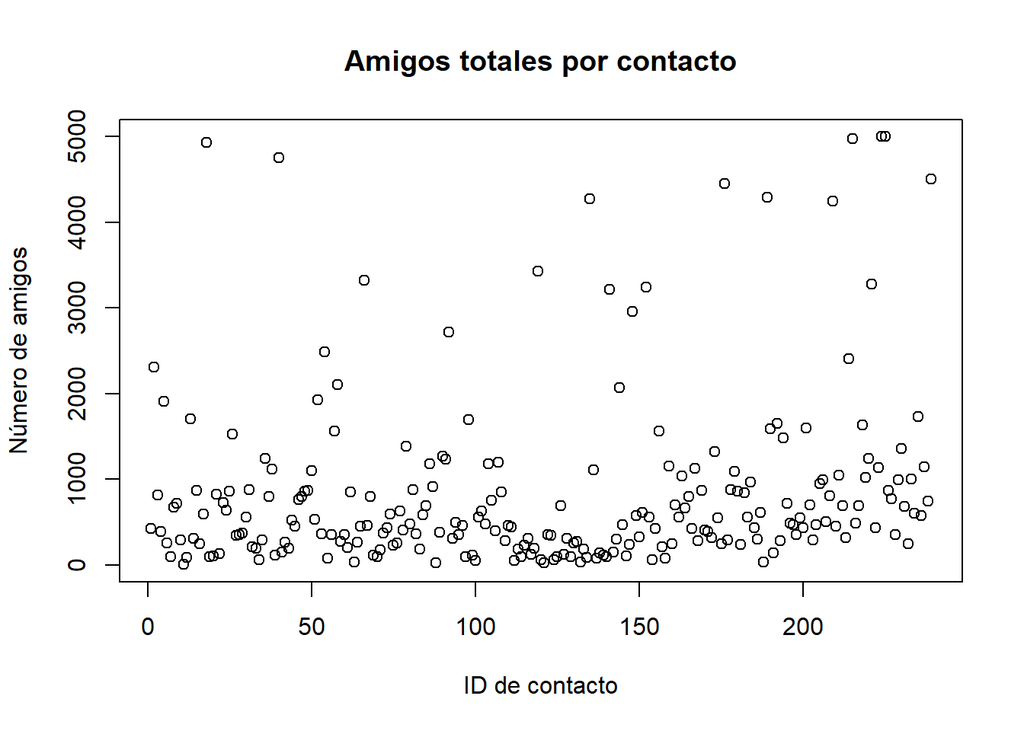

```r
plot(am_to1,xlab="ID de contacto",ylab="Número de amigos",main="Amigos totales por contacto")
```

Se puede observar que existen al menos 10 contactos que superan los 4000 amigos en su lista de amistades, mientras que hay contactos que llegan a lo más a 5 contactos, siendo el promedio de 850 amigos, sin embargo la mediana dista del promedio por al menos 300 amigos de diferencia, también el valor de la desviación estándar es muy grande

Con el “Boxplot” trataremos de determinar cuántos “outliers” existen en la distribución

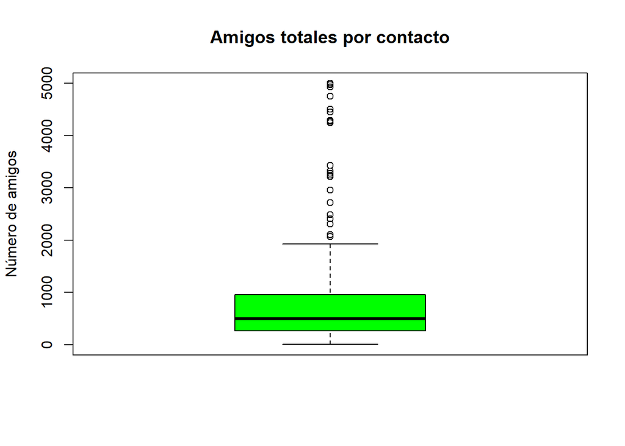

```r
boxplot(am_to1,ylab="Número de amigos",main="Amigos totales por contacto",col = "green")
```

Se ve claramente la existencia de muchos “Outliers”

Por último graficaremos la distribución de los datos

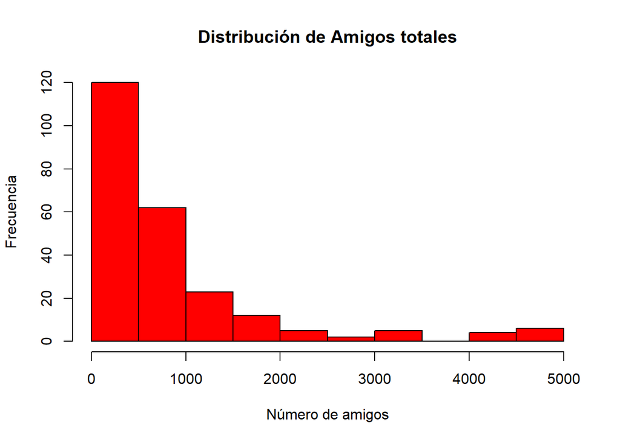

```r
hist(am_to1,xlab="Número de amigos",ylab="Frecuencia",main="Distribución de Amigos totales",col = "red")
```

Vemos una distribución cargada hacia la izquierda, sin embargo, aplicaremos la prueba de normalidad para obtener un resultado estadístico significativo

```r
shapiro.test(am_to1)
```

```
##
##  Shapiro-Wilk normality test
##
## data:  am_to1
## W = 0.68035, p-value < 2.2e-16
```

Con el p-value obtenido rechazamos la hipótesis de normalidad en la distribución de amigos totales

Ahora se ve por frecuencia de contactos cuántos amigos tienen

```r
frec_am_to<-sort(table(as.factor(am_to)),decreasing = TRUE)
head(frec_am_to,63)
```

```
##
##  245 amigos  687 amigos  100 amigos  117 amigos  266 amigos  288 amigos
##           3           3           2           2           2           2
##  308 amigos  354 amigos 4998 amigos   59 amigos  878 amigos   93 amigos
##           2           2           2           2           2           2
##   98 amigos 1004 amigos  101 amigos 1024 amigos  103 amigos 1036 amigos
##           2           1           1           1           1           1
## 1050 amigos 1095 amigos 1103 amigos 1106 amigos  111 amigos 1119 amigos
##           1           1           1           1           1           1
## 1123 amigos 1137 amigos  114 amigos 1141 amigos 1153 amigos 1179 amigos
##           1           1           1           1           1           1
## 1182 amigos 1198 amigos  121 amigos 1229 amigos 1240 amigos 1245 amigos
##           1           1           1           1           1           1
##  125 amigos 1273 amigos 1321 amigos  133 amigos 1359 amigos  136 amigos
##           1           1           1           1           1           1
## 1381 amigos  144 amigos 1484 amigos  150 amigos  151 amigos 1527 amigos
##           1           1           1           1           1           1
## 1558 amigos 1559 amigos 1590 amigos 1597 amigos 1634 amigos 1648 amigos
##           1           1           1           1           1           1
## 1691 amigos 1705 amigos  172 amigos 1733 amigos  181 amigos  185 amigos
##           1           1           1           1           1           1
##  187 amigos  190 amigos 1913 amigos
##           1           1           1
```

Revisamos que amigos tienen el valor mínimo y máximo de amigos totales

```r
fbFr3[21,]
```

```
##    No.Contacto      Nombre     Info
## 21          21 Fritz Wurtz 5 amigos
```

```r
fbFr3[345,]
```

```
##     No.Contacto       Nombre        Info
## 345         345 Kennia Duran 4998 amigos
```

```r
fbFr3[346,]
```

```
##     No.Contacto      Nombre        Info
## 346         346 Dorel Golan 4998 amigos
```

Se sigue con el análisis de la categoría “Amigos en común”

```r
am_co<-unlist(str_extract_all(fbFr3$Info,"[:digit:]{1,} amigos en común"))
head(am_co)
```

```
## [1] "71 amigos en común" "61 amigos en común" "23 amigos en común"
## [4] "17 amigos en común" "15 amigos en común" "42 amigos en común"
```

```r
tail(am_co)
```

```
## [1] "2 amigos en común" "2 amigos en común" NA
## [4] NA                  NA                  NA
```

Se extraen los “NA” y se continua con la extracción de sólo los números

```r
am_co<-am_co[1:107]
am_co1<-unlist(str_extract_all(am_co,"[:digit:]{1,}"))
head(am_co1,30)
```

```
##  [1] "71" "61" "23" "17" "15" "42" "67" "18" "33" "16" "17" "73" "23" "3"
## [15] "12" "13" "2"  "41" "25" "5"  "15" "54" "61" "74" "74" "5"  "27" "14"
## [29] "7"  "21"
```

Se transforma la variable a númerica, se aplica un summary y se calcula la desviación estándar

```r
am_co1<-as.numeric(am_co1)
round(summary(am_co1))
```

```
##    Min. 1st Qu.  Median    Mean 3rd Qu.    Max.
##       2      12      21      27      40      74
```

```r
round(sd(am_co1))
```

```
## [1] 21
```

Se grafican los datos obtenidos

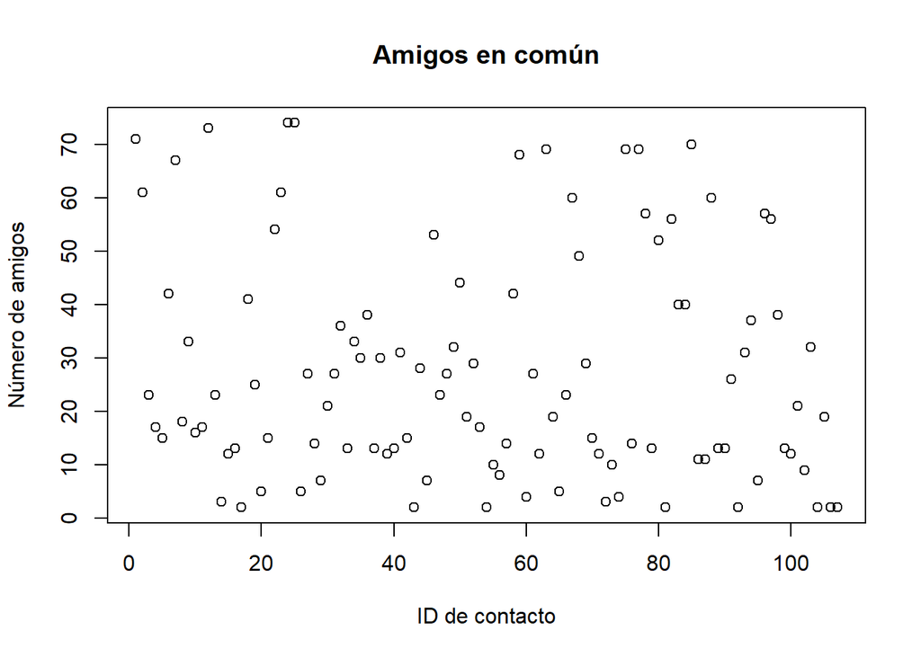

```r
plot(am_co1,xlab="ID de contacto",ylab="Número de amigos",main="Amigos en común")
```

Se puede observar que existen al menos 10 contactos que superan los 60 amigos en común en mi lista de amistades, mientras que hay contactos que llegan a lo más a 2 amigos en común, siendo el promedio de 27 amigos en común, y el valor de la desviación estándar es de 21 amigos

Con el “Boxplot” trataremos de determinar cuántos “outliers” existen en la distribución

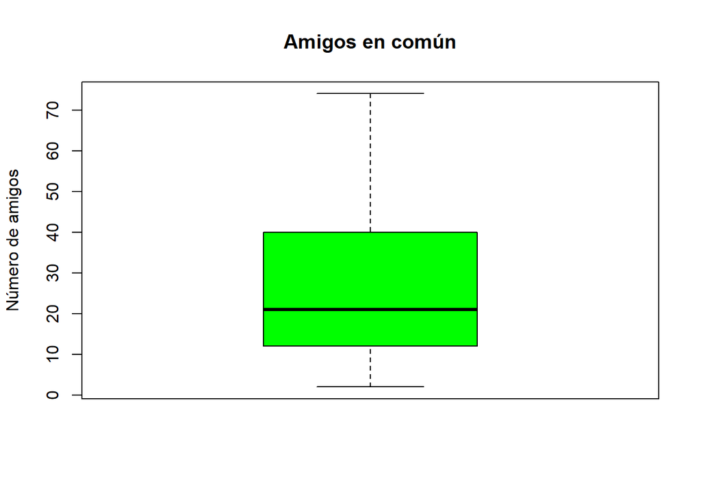

```r
boxplot(am_co1,ylab="Número de amigos",main="Amigos en común",col = "green")
```

No hay existencia de “Outliers”

Por último graficaremos la distribución de los datos

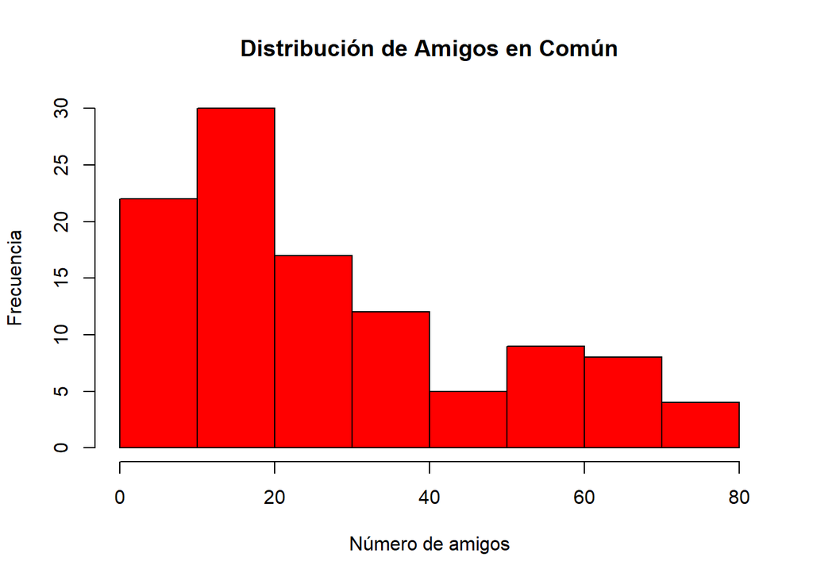

```r
hist(am_co1,xlab="Número de amigos",ylab="Frecuencia",main="Distribución de Amigos en Común",col = "red")
```

También vemos una distribución cargada hacia la izquierda, sin embargo, aplicaremos la prueba de normalidad para obtener un resultado estadístico significativo

```r
shapiro.test(am_co1)
```

```
##
##  Shapiro-Wilk normality test
##
## data:  am_co1
## W = 0.8973, p-value = 5.156e-07
```

Con el p-value obtenido rechazamos la hipótesis de normalidad en la distribución de amigos en común

Ahora se ve por frecuencia de contactos cuántos amigos en común se tienen

```r
frec_am_co<-sort(table(as.factor(am_co)),decreasing = TRUE)
head(frec_am_co,63)
```

```
##
## 13 amigos en común  2 amigos en común 12 amigos en común
##                  8                  8                  5
## 15 amigos en común 23 amigos en común 27 amigos en común
##                  4                  4                  4
## 14 amigos en común 17 amigos en común 19 amigos en común
##                  3                  3                  3
##  5 amigos en común 69 amigos en común  7 amigos en común
##                  3                  3                  3
## 10 amigos en común 11 amigos en común 21 amigos en común
##                  2                  2                  2
## 29 amigos en común  3 amigos en común 30 amigos en común
##                  2                  2                  2
## 31 amigos en común 32 amigos en común 33 amigos en común
##                  2                  2                  2
```

[output cut: 20 more lines]

Revisamos que amigos tienen el valor mínimo y máximo de amigos en común

```r
fbFr3[c(43,134,159),]
```

```
##     No.Contacto                Nombre              Info
## 43           43      Carmen Caballero 2 amigos en común
## 134         134          Aby Balderas 2 amigos en común
## 159         159 Nonantzin Pineda Ruiz 2 amigos en común
```

```r
fbFr3[c(74,76),]
```

```
##    No.Contacto         Nombre               Info
## 74          74 Pancho Morales 74 amigos en común
## 76          76   Josué Garcia 74 amigos en común
```

Para finalizar se hace un breve análisis sobre la información general que se puedo obtener de los contactos

```r
i_g<-unlist(str_extract_all(fbFr3$Info,"[A-Z][[A-Z][a-z][:punct:] ]{2,}"))
i_g<-i_g[-c(9:10,28:31)]
i_g
```

```
##  [1] "Facultad de Medicina UAEM"
##  [2] "Medicina Familiar Servicio Social en Hospital Rural Prospera IMSS Mamantel"
##  [3] "Trabaja en Chong Hua Hospital"
##  [4] "Trabaja en TECBOT"
##  [5] "CIMAT"
##  [6] "Trabaja en wili wonka chocolate factory"
##  [7] "Bartender en Bartenders"
##  [8] "Universidad Aut"
##  [9] "Trabaja en Robert Bosch Toluca"
## [10] "Trabaja en TRX Mexico"
## [11] "Trabaja en HIDRIONICOS"
## [12] "Sultepec"
## [13] "Lecce"
## [14] "UAEMex"
## [15] "Codian Constructora"
## [16] "Toluca de Lerdo"
## [17] "Trabaja en Modelo y Edecan"
## [18] "Gerente en Comas Api"
## [19] "Staff en Autoridad Del Espacio P"
## [20] "Trabaja en OH AL"
## [21] "Public Relations Assistant en Be M"
## [22] "Gerente en SKECHERS"
## [23] "Teacher en American School Foundation of Chiapas A.C."
## [24] "EBC TOLUCA"
## [25] "Trabaja en Bonafont"
```

Podemos ver que algunas palabras están incompletas, esto debido a los acentos, por lo que completaremos las palabras (sin acento)

```r
g1<-str_replace(i_g, pattern = "Universidad Aut", replacement = "Universidad Autonoma Benito Juarez")
g2<-str_replace(g1,pattern="Staff en Autoridad Del Espacio P",replacement="Staff en Autoridad Del Espacio Publico")
g3<-str_replace(g2, pattern = "Trabaja en OH AL", replacement = "Trabaja en OH ALA")
g4<-str_replace(g3, pattern = "Public Relations Assistant en Be M", replacement = "Public Relations Assistant en Be Mexico")
ginF<-g4
ginF
```

```
##  [1] "Facultad de Medicina UAEM"
##  [2] "Medicina Familiar Servicio Social en Hospital Rural Prospera IMSS Mamantel"
##  [3] "Trabaja en Chong Hua Hospital"
##  [4] "Trabaja en TECBOT"
##  [5] "CIMAT"
##  [6] "Trabaja en wili wonka chocolate factory"
##  [7] "Bartender en Bartenders"
##  [8] "Universidad Autonoma Benito Juarez"
##  [9] "Trabaja en Robert Bosch Toluca"
## [10] "Trabaja en TRX Mexico"
## [11] "Trabaja en HIDRIONICOS"
## [12] "Sultepec"
## [13] "Lecce"
## [14] "UAEMex"
## [15] "Codian Constructora"
## [16] "Toluca de Lerdo"
## [17] "Trabaja en Modelo y Edecan"
## [18] "Gerente en Comas Api"
## [19] "Staff en Autoridad Del Espacio Publico"
## [20] "Trabaja en OH ALA"
## [21] "Public Relations Assistant en Be Mexico"
## [22] "Gerente en SKECHERS"
## [23] "Teacher en American School Foundation of Chiapas A.C."
## [24] "EBC TOLUCA"
## [25] "Trabaja en Bonafont"
```

Teniendo la tabla corregida se procede con el análisis, el cual consistirá en crear una “Corpora” inicialmente

```r
corp1<-Corpus(VectorSource(ginF))
corp1<-tm_map(corp1, removePunctuation)
corp1<-tm_map(corp1, content_transformer(tolower))
```

Creamos la matriz Term-Document

```r
term.matrix1<-TermDocumentMatrix(corp1)
term.matrix1<-as.matrix(term.matrix1)
head(term.matrix1)
```

```
##           Docs
## Terms      1 2 3 4 5 6 7 8 9 10 11 12 13 14 15 16 17 18 19 20 21 22 23 24
##   facultad 1 0 0 0 0 0 0 0 0  0  0  0  0  0  0  0  0  0  0  0  0  0  0  0
##   medicina 1 1 0 0 0 0 0 0 0  0  0  0  0  0  0  0  0  0  0  0  0  0  0  0
##   uaem     1 0 0 0 0 0 0 0 0  0  0  0  0  0  0  0  0  0  0  0  0  0  0  0
##   familiar 0 1 0 0 0 0 0 0 0  0  0  0  0  0  0  0  0  0  0  0  0  0  0  0
##   hospital 0 1 1 0 0 0 0 0 0  0  0  0  0  0  0  0  0  0  0  0  0  0  0  0
##   imss     0 1 0 0 0 0 0 0 0  0  0  0  0  0  0  0  0  0  0  0  0  0  0  0
##           Docs
## Terms      25
##   facultad  0
##   medicina  0
##   uaem      0
##   familiar  0
##   hospital  0
##   imss      0
```

Continuamos con la creación de la tabla de frecuencias

```r
word_freqs1<-sort(rowSums(term.matrix1),decreasing=TRUE)
dm1<-data.frame(word=names(word_freqs1),freq=word_freqs1)
head(dm1,10)
```

```
##              word freq
## trabaja   trabaja    9
## toluca     toluca    3
## medicina medicina    2
## hospital hospital    2
## mexico     mexico    2
## gerente   gerente    2
## facultad facultad    1
## uaem         uaem    1
## familiar familiar    1
## imss         imss    1
```

Graficamos

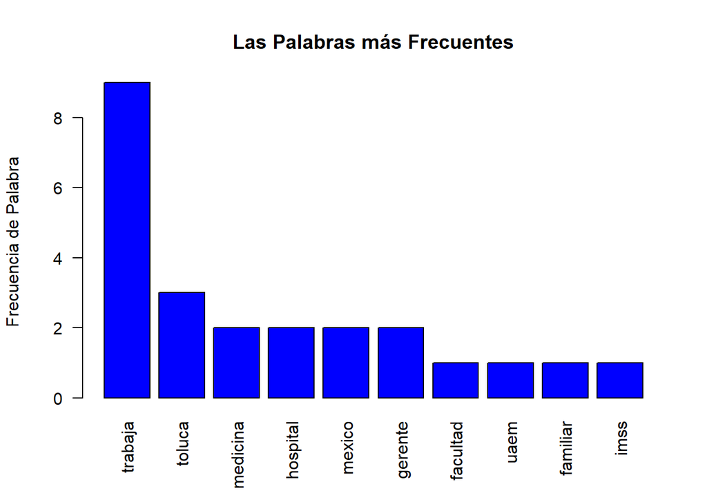

```r
barplot(dm1[1:10,]$freq,las=2,names.arg=dm1[1:10,]$word,
        col="blue",main="Las Palabras más Frecuentes",ylab="Frecuencia de Palabra")
```

Finalmente, graficamos la “Word Cloud”

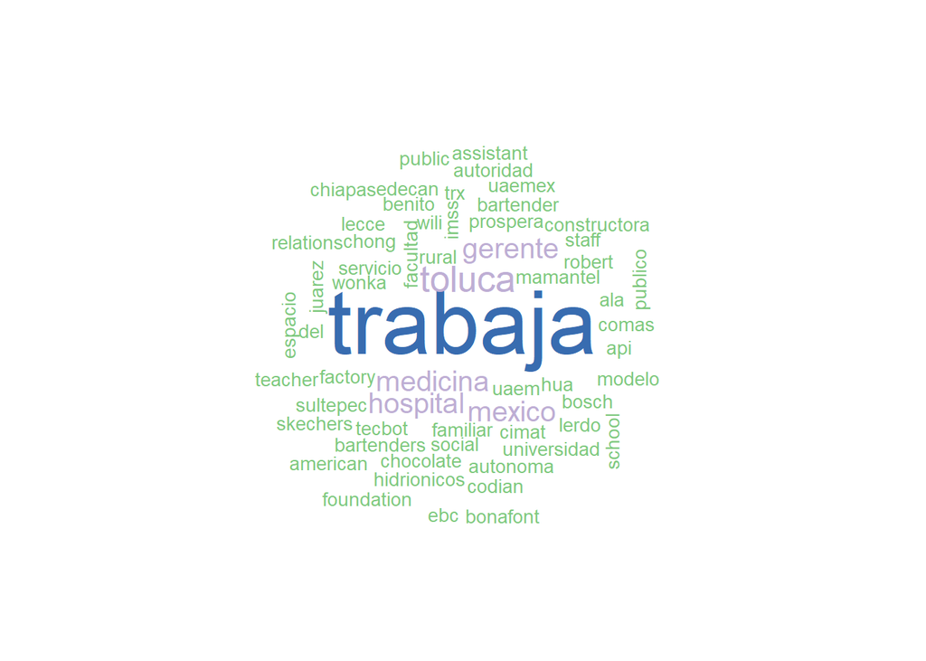

```r
wordcloud(dm1$word, dm1$freq, random.order=FALSE,colors=brewer.pal(5, "Accent"),min.freq = 1)
```

Con esto concluímos el análisis de la información recopilada de mis contactos de Facebook. Como una breve conclusión, se puede notar la importancia que los datos pueden tomar en algo tan simple y que muchas veces pueden pasar completamente desapercibidos por las personas.